# Data Handling: Import, Cleaning and Visualisation

## Merging (joining) datasets: concept

*Merge all x: Left join*

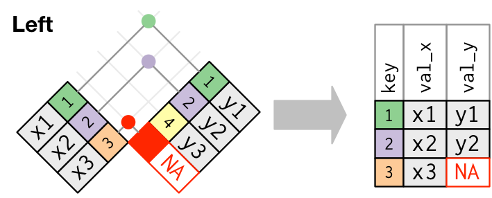

Outer join. Source: Wickham and Grolemund (2017), licensed under the [Creative Commons Attribution-Share Alike 3.0 United States](https://creativecommons.org/licenses/by-nc-nd/3.0/us/) license.

## Merging (joining) datasets: concept

*Merge all y: Right join*

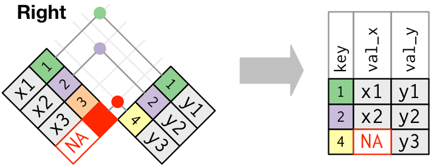

Outer join. Source: Wickham and Grolemund (2017), licensed under the [Creative Commons Attribution-Share Alike 3.0 United States](https://creativecommons.org/licenses/by-nc-nd/3.0/us/) license.

## Merging (joining) datasets: concept

*Merge all x and all y: Full join*

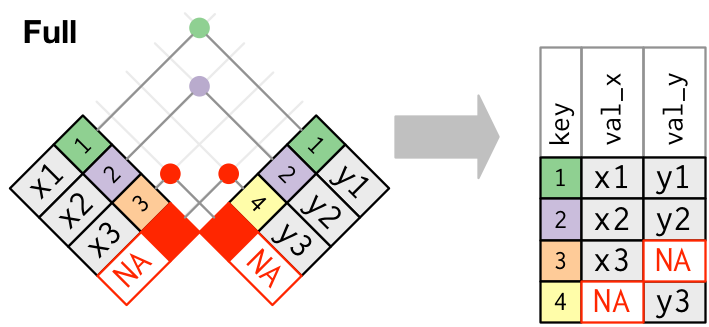

Outer join. Source: Wickham and Grolemund (2017), licensed under the [Creative Commons Attribution-Share Alike 3.0 United States](https://creativecommons.org/licenses/by-nc-nd/3.0/us/) license.

## Merging (joining) datasets: R

Overview by Wickham and Grolemund (2017):

| dplyr (tidyverse) | base::merge |
| --- | --- |
| `inner_join(x, y)` | `merge(x, y)` |
| `left_join(x, y)` | `merge(x, y, all.x = TRUE)` |
| `right_join(x, y)` | `merge(x, y, all.y = TRUE)`, |
| `full_join(x, y)` | `merge(x, y, all.x = TRUE, all.y = TRUE)` |

## Data Summaries: Selecting, Filtering, and Mutating

## Data summaries

- First step of analysis.
- Get overview over dataset.
- Show key aspects of data.
  - Inform your own statistical analysis.
  - Inform audience (helps understand advanced analytics parts)

## Data summaries: first steps

- *Select* subset of variables (e.g., for comparisons).
- *Filter* the dataset (some observations not needed in *this* analysis).
- *Mutate* the dataset: additional values needed

## Select, filter, mutate in R (tidyverse)

- `select()`
- `filter()`
- `mutate()`

## Data Summaries: Aggregate Statistics

## Descriptive/aggregate statistics

- Overview of key characteristics of main variables used in analysis.
- Key characteristics:
  - mean
  - standard deviation
  - No. of observations
  - etc.

## Aggregate statistics in R

1. Function to compute statistic (`mean()`).
2. Function to *apply* the statistics function to one or several columns in a tidy dataset.
- All values.
- By group (observation categories, e.g. by gender)

## Aggregate statistics in R

- `summarise()` (in `tidyverse`)
- `group_by()` (in `tidyverse`)
- `sapply()`, `apply()`, `lapply()`, etc. (in `base`)

## Data Analytics: a primer in linear regression/OLS

## Statistical modelling perspective

- *Dependent variable*: \(y_i\).
- *Explanatory variable*: \(x_i\).
- “All the rest”: \(u_{i}\) (the *‘residuals’* or the ‘error term’).

\(y_{i}= \alpha + \beta x_{i} + u_{i}\).

## Statistical modelling perspective: causality?

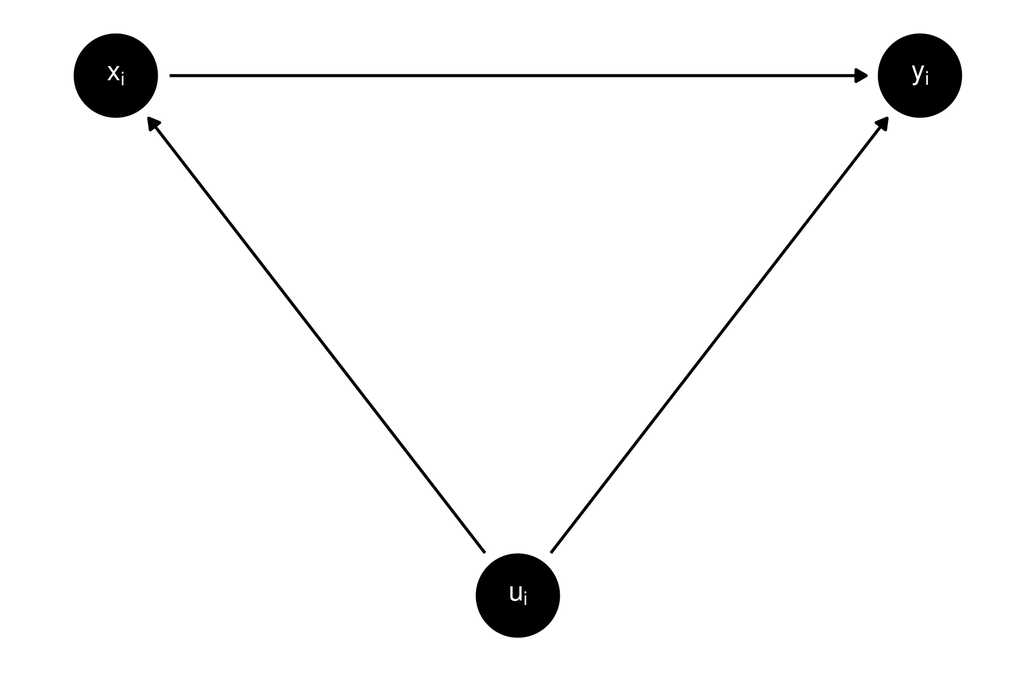

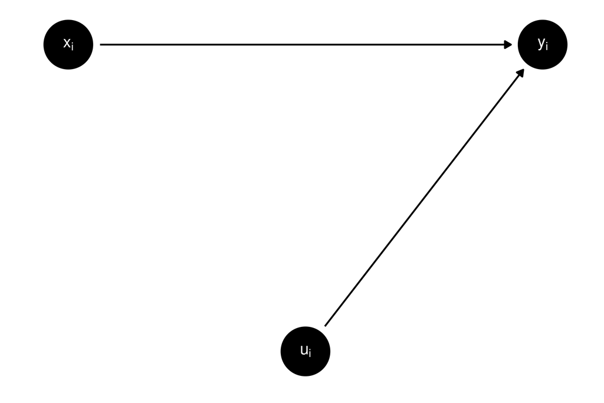

## Illustration with pseudo-data

First, we define the key parameters for the simulation. We choose the actual values of \(\alpha\) and \(\beta\), and set the number of observations \(N\).

```r
alpha <- 30
beta <- 0.9
N <- 1000
```

## Illustration with pseudo-data

```r
x <- runif(N, 0, 50)
```

## Illustration with pseudo-data

```r
# draw the random errors (all the other factors also affecting y)
epsilon <- rnorm(N, sd=10)
# compute the dependent variable values
y <- alpha + beta*x + epsilon
```

## Illustration with pseudo-data

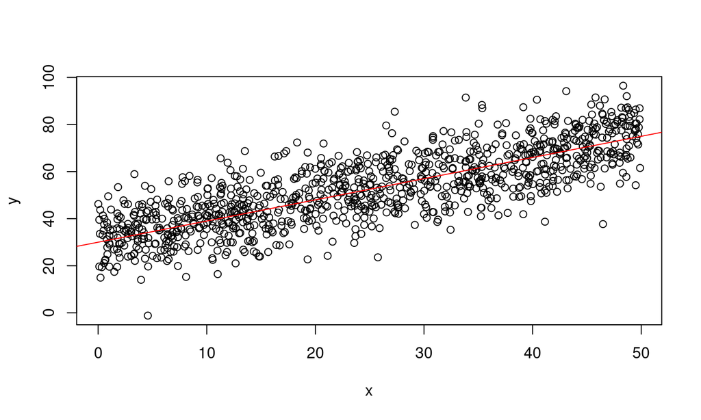

```r
plot(x,y)
abline(a = alpha, b=beta, col="red")
```

## Illustration with pseudo data: “averaging”

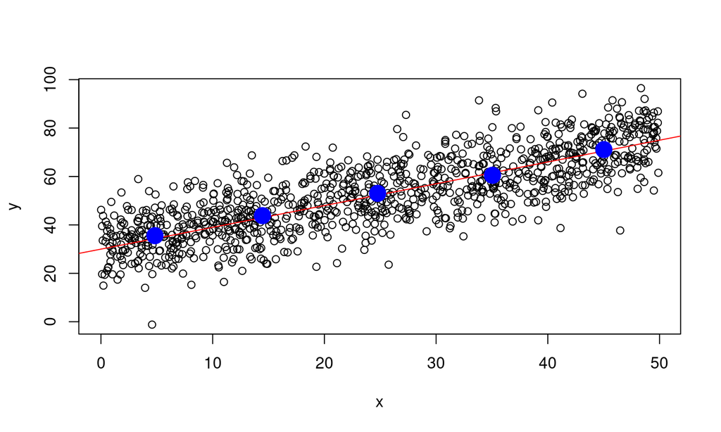

```r
# compute average y per x intervals
lower <- c(0,10,20,30,40)
upper <- c(lower[-1], 50)
n_intervals <- length(lower)
y_bars <- list()
length(y_bars) <- n_intervals
x_bars <- list()
length(x_bars) <- n_intervals
for (i in 1:n_intervals){
  y_bars[i] <- mean(y[lower[i] <= x & x < upper[i]])
  x_bars[i] <- mean(x[lower[i] <= x & x < upper[i]])

}
y_bars <- unlist(y_bars)
x_bars <- unlist(x_bars)

# add to plot
plot(x,y)
abline(a = alpha, b=beta, col="red")
points(x_bars, y_bars, col="blue", lwd=10)
```

## Parameter estimation: “average out the \(u\)”

Clearly, the average values are much closer to the real values. That is, we can ‘average out’ the \(u\) in order to get a good estimate for the effect of \(x\) on \(y\) (to get an estimate of \(\beta\)). With this understanding, we can now formalize how to compute \(\beta\) (or, to be more precise, an estimate of it: \(\hat{\beta}\)). For simplicity, we take \(\alpha=30\) as given.

In a first step we take the averages of both sides of our initial regression equation:

\(\frac{1}{N}\sum{y_i}=\frac{1}{N}\sum{(30 + \beta x_{i} + u_{i})}\),

rearranging and using the common ‘bar’-notation for means, we get

\(\bar{y}=30+\beta\bar{x} + \bar{u}\),

and solving for \(\beta\) and some rearranging then yields

\(\beta=\frac{\bar{y}-30-\bar{u}}{\bar{x}}\).

## Parameter estimation: “average out the \(u\)”

While the elements in \(\bar{u}\) are unobservable, we can use the rest to compute an estimate of \(\beta\):

\(\hat{\beta}=\frac{\bar{y}-30}{\bar{x}}\).

```r
(mean(y) -30)/mean(x)
```

```
## [1] 0.9187287
```

## Data analytics perspective and estimation: data

```r
# load the data
data(swiss)
# look at the description
?swiss
```

## Data analytics perspective and estimation: research question

- Do more years of schooling improve educational outcomes?
- Approximate educational attainment with the variable `Education` and educational outcomes with the variable `Examination`.
- Make use of the simple linear model to investigate whether more schooling improves educational outcomes (on average)?

## Model specification

\(Examination_{i}= \alpha + \beta Education_{i}\),

- Intuitive hypothesis: \(\beta\) is positive, indicating that a higher share of draftees with more years of schooling results in a higher share of draftees who reach the highest examination mark.
- *Problems*?

## Model specification

To formally acknowledge that other factors might also play a role, we extend our model with the term \(u_{i}\). For the moment, we thus subsume all other potentially relevant factors in that term:

\(Examination_{i}= \alpha + \beta Education_{i} + u_{i}\).

## Raw data

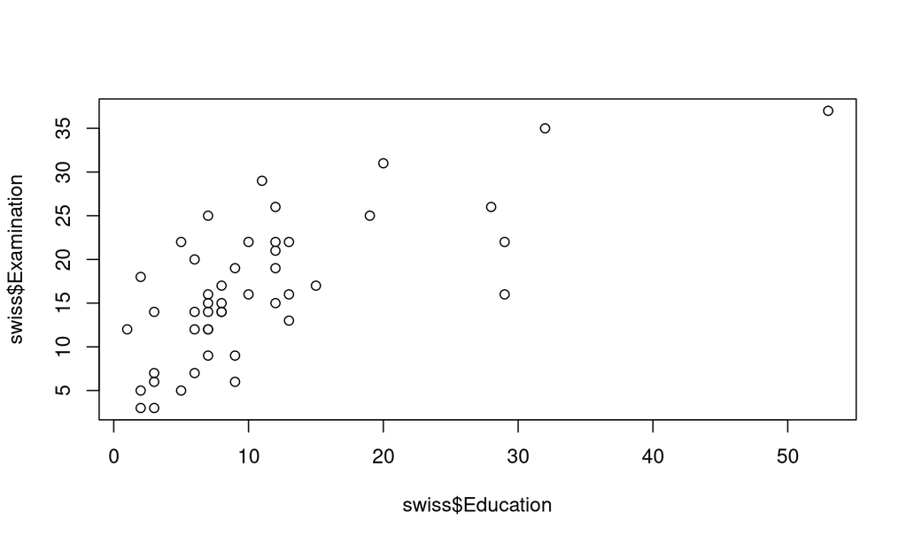

```r
plot(swiss$Education, swiss$Examination)
```

## Derivation and implementation of OLS estimator

From the model equation we easily see that these ‘differences’ between the predicted and the actual values of \(y\) are the remaining unexplained component \(u\):

\(y_{i}-\hat{\alpha}-\hat{\beta} x_i=u_i\).

Hence, we want to minimize the *sum of squared residuals (SSR)*: \(\sum{u_i^2}=\sum{(y_{i}-\hat{\alpha}-\hat{\beta} x_i)^2}\). Using calculus, we define the two first order conditions:

\[\frac{\partial SSR}{\partial \hat{\alpha}}=\sum{-2(y_{i}-\hat{\alpha}-\hat{\beta} x_i)}=0\]

\[\frac{\partial SSR}{\partial \hat{\beta}}=\sum{-2x_i(y_{i}-\hat{\alpha}-\hat{\beta} x_i)}=0\]

## Derivation and implementation of OLS estimator

The first condition is relatively easily solved by getting rid of the \(-2\) and considering that \(\sum{y_i}=N\bar{y}\): \(\hat{\alpha}=\bar{y}-\hat{\beta}\bar{x}\).

## Derivation and implementation of OLS estimator

By plugging the solution for \(\hat{\alpha}\) into the first order condition regarding \(\hat{\beta}\) and again considering that \(\sum{y_i}=N\bar{y}\), we get the solution for the slope coefficient estimator:

\(\frac{\sum{x_{i}y_{i}}-N\bar{y}\bar{x}}{\sum{x_i^2}-N\bar{x}^2}\).

## OLS estimator in R!

```r
# implement the simple OLS estimator
# verify implementation with simulated data from above
# my_ols(y,x)
# should be very close to alpha=30 and beta=0.9
my_ols <-
  function(y,x) {
    N <- length(y)
    betahat <- (sum(y*x) - N*mean(x)*mean(y)) / (sum(x^2)-N*mean(x)^2)
    alphahat <- mean(y)-betahat*mean(x)

    return(list(alpha=alphahat,beta=betahat))
  }

# estimate effect of Education on Examination
estimates <- my_ols(swiss$Examination, swiss$Education)
estimates
```

```
## $alpha
## [1] 10.12748
##
## $beta
## [1] 0.5794737
```

## Simple visualisation

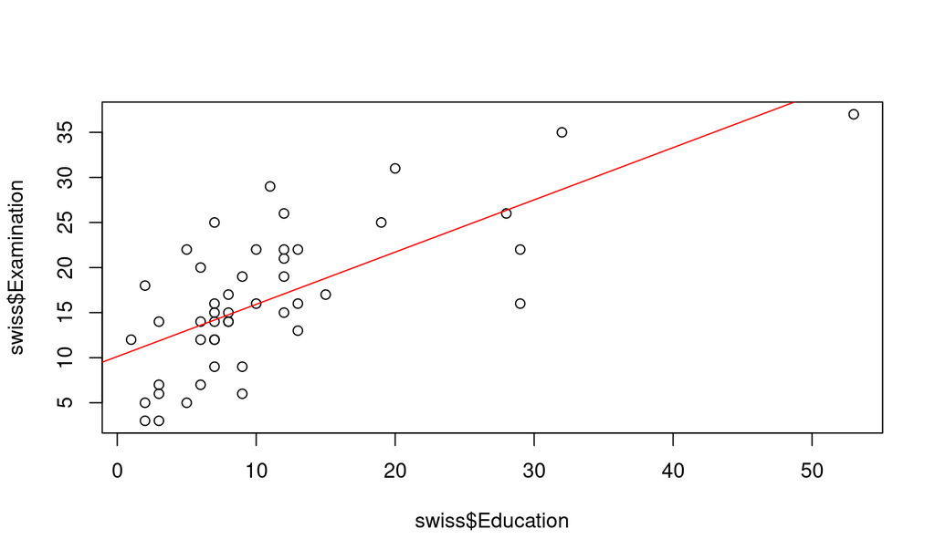

```r
plot(swiss$Education, swiss$Examination)
abline(estimates$alpha, estimates$beta, col="red")
```

## Regression toolbox in R

```r
estimates2 <- lm(Examination~Education, data=swiss)
estimates2
```

```
##
## Call:
## lm(formula = Examination ~ Education, data = swiss)
##
## Coefficients:
## (Intercept)    Education
##     10.1275       0.5795
```

With one additional line of code we can compute all the common statistics about the regression estimation:

```r
summary(estimates2)
```

```
##
## Call:
## lm(formula = Examination ~ Education, data = swiss)
##
## Residuals:
##      Min       1Q   Median       3Q      Max
## -10.9322  -4.7633  -0.1838   3.8907  12.4983
##
## Coefficients:
##             Estimate Std. Error t value Pr(>|t|)
## (Intercept) 10.12748    1.28589   7.876 5.23e-10 ***
## Education    0.57947    0.08852   6.546 4.81e-08 ***
## ---
## Signif. codes:  0 '***' 0.001 '**' 0.01 '*' 0.05 '.' 0.1 ' ' 1
##
## Residual standard error: 5.773 on 45 degrees of freedom
## Multiple R-squared:  0.4878, Adjusted R-squared:  0.4764
## F-statistic: 42.85 on 1 and 45 DF,  p-value: 4.811e-08
```

## Q&A

## References

Wickham, Hadley. 2014. “Tidy Data.” *Journal of Statistical Software* 59 (10): 1–23. https://doi.org/10.18637/jss.v059.i10.